# AbaloneAge

###### Importing libraries and the dataset

```python
import numpy as np
import pandas as pd
import matplotlib.pyplot as plt
%matplotlib inline
import seaborn as sns
import warnings
warnings.filterwarnings('ignore')

from sklearn.preprocessing import OneHotEncoder
from sklearn.model_selection import train_test_split
from sklearn.linear_model import LinearRegression
from sklearn.svm import SVC

from scipy.stats import chi2
sns.set()
```

```python
df = pd.read_csv("./abalone.csv")
```

Sneak peek into the dataset.

```python
df
```

|  | Sex | Length | Diameter | Height | Whole weight | Shucked weight | Viscera weight | Shell weight | Rings |
| --- | --- | --- | --- | --- | --- | --- | --- | --- | --- |
| 0 | M | 0.455 | 0.365 | 0.095 | 0.5140 | 0.2245 | 0.1010 | 0.1500 | 15 |
| 1 | M | 0.350 | 0.265 | 0.090 | 0.2255 | 0.0995 | 0.0485 | 0.0700 | 7 |
| 2 | F | 0.530 | 0.420 | 0.135 | 0.6770 | 0.2565 | 0.1415 | 0.2100 | 9 |
| 3 | M | 0.440 | 0.365 | 0.125 | 0.5160 | 0.2155 | 0.1140 | 0.1550 | 10 |
| 4 | I | 0.330 | 0.255 | 0.080 | 0.2050 | 0.0895 | 0.0395 | 0.0550 | 7 |
| ... | ... | ... | ... | ... | ... | ... | ... | ... | ... |
| 4172 | F | 0.565 | 0.450 | 0.165 | 0.8870 | 0.3700 | 0.2390 | 0.2490 | 11 |
| 4173 | M | 0.590 | 0.440 | 0.135 | 0.9660 | 0.4390 | 0.2145 | 0.2605 | 10 |
| 4174 | M | 0.600 | 0.475 | 0.205 | 1.1760 | 0.5255 | 0.2875 | 0.3080 | 9 |
| 4175 | F | 0.625 | 0.485 | 0.150 | 1.0945 | 0.5310 | 0.2610 | 0.2960 | 10 |
| 4176 | M | 0.710 | 0.555 | 0.195 | 1.9485 | 0.9455 | 0.3765 | 0.4950 | 12 |

4177 rows × 9 columns

### Data Analysis

#### Checking missing values

```python
print(df.info())
```

```
<class 'pandas.core.frame.DataFrame'>
RangeIndex: 4177 entries, 0 to 4176
Data columns (total 9 columns):
 #   Column          Non-Null Count  Dtype
---  ------          --------------  -----
 0   Sex             4177 non-null   object
 1   Length          4177 non-null   float64
 2   Diameter        4177 non-null   float64
 3   Height          4177 non-null   float64
 4   Whole weight    4177 non-null   float64
 5   Shucked weight  4177 non-null   float64
 6   Viscera weight  4177 non-null   float64
 7   Shell weight    4177 non-null   float64
 8   Rings           4177 non-null   int64
dtypes: float64(7), int64(1), object(1)
memory usage: 293.8+ KB
None
```

We have one column with categorical data ($\texttt{Sex}$), seven with continuous data ($\texttt{Length}$, $\texttt{Diameter}$, $\texttt{Height}$, $\texttt{Whole weight}$, $\texttt{Shucked weight}$, $\texttt{Viscera weight}$, $\texttt{Shell weight}$) and one column with discrete data ($\texttt{Rings}$).

Note about the different weight variables - $\texttt{Shucked weight}$ is the weight of meat, $\texttt{Viscera weight}$ is the gut weight after bleeding and $\texttt{Shell weight}$ is the weight after drying.

```python
df.duplicated().sum()
```

```
0
```

We see there are no missing nor duplicates values in the data set.

#### Univariate analysis

Let us now look into summary statistics.

```python
df[['Length', 'Diameter', 'Height', 'Whole weight', 'Shucked weight', 'Viscera weight', 'Shell weight', 'Rings']].describe()
```

|  | Length | Diameter | Height | Whole weight | Shucked weight | Viscera weight | Shell weight | Rings |
| --- | --- | --- | --- | --- | --- | --- | --- | --- |
| count | 4177.000000 | 4177.000000 | 4177.000000 | 4177.000000 | 4177.000000 | 4177.000000 | 4177.000000 | 4177.000000 |
| mean | 0.523992 | 0.407881 | 0.139516 | 0.828742 | 0.359367 | 0.180594 | 0.238831 | 9.933684 |
| std | 0.120093 | 0.099240 | 0.041827 | 0.490389 | 0.221963 | 0.109614 | 0.139203 | 3.224169 |
| min | 0.075000 | 0.055000 | 0.000000 | 0.002000 | 0.001000 | 0.000500 | 0.001500 | 1.000000 |
| 25% | 0.450000 | 0.350000 | 0.115000 | 0.441500 | 0.186000 | 0.093500 | 0.130000 | 8.000000 |
| 50% | 0.545000 | 0.425000 | 0.140000 | 0.799500 | 0.336000 | 0.171000 | 0.234000 | 9.000000 |
| 75% | 0.615000 | 0.480000 | 0.165000 | 1.153000 | 0.502000 | 0.253000 | 0.329000 | 11.000000 |
| max | 0.815000 | 0.650000 | 1.130000 | 2.825500 | 1.488000 | 0.760000 | 1.005000 | 29.000000 |

Notice that the minimun value in $\texttt{Height}$ column is 0. We will remove those data points, since essentially they have a missing value.

```python
print(df[df['Height'] == 0])
df = df[df['Height'] > 0]
```

```
     Sex  Length  Diameter  Height  Whole weight  Shucked weight  \
1257   I   0.430      0.34     0.0         0.428          0.2065
3996   I   0.315      0.23     0.0         0.134          0.0575

      Viscera weight  Shell weight  Rings
1257          0.0860        0.1150      8
3996          0.0285        0.3505      6
```

For more succinct code, we will define the list of continuous variables.

```python
num_vars = ['Length', 'Diameter', 'Height', 'Whole weight', 'Shucked weight', 'Viscera weight', 'Shell weight']
```

##### Sex

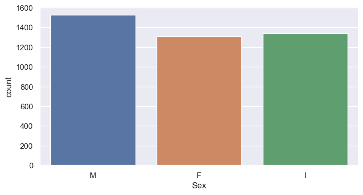

```python
sns.countplot(df, x='Sex')
```

Notice we have two types of speciments in the dataset, infants and adults (male and female)

##### Rings

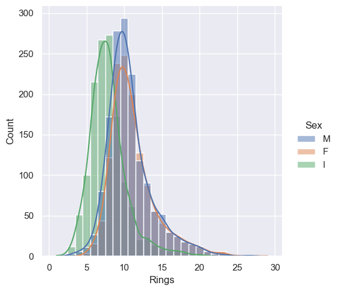

```python
sns.displot(df, x='Rings', discrete=True, kde=True, hue='Sex')
```

Observe that sexual maturity comes at different age for different shells in the datasets. We can see that from this graph of distribution of $\texttt{Rings}$ variable stratified by sex ($\texttt{Infant}$, $\texttt{Female}$, $\texttt{Male}$)

Next,let's see the box plots to familiarize ouselves with the state of outliers

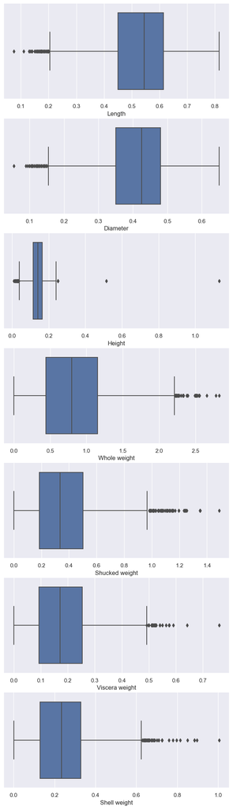

```python
sns.set(rc={"figure.figsize":(8, 28)})
fig, axes = plt.subplots(7, 1)

for i, var in zip(range(len(num_vars)), num_vars):
    sns.boxplot(df, x=var, ax = axes[i])

sns.set(rc={"figure.figsize":(8, 4)})
```

Notice that quite a few data points fall into the outlier category.

Visualizing the relationship with the response variable - number of rings

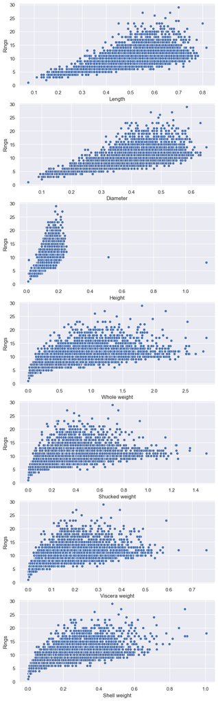

```python
sns.set(rc={"figure.figsize":(8, 28)})
fig, axes = plt.subplots(7, 1)

for i, var in zip(range(len(num_vars)), num_vars):
    sns.scatterplot(df, x=var, y=df.Rings, ax = axes[i])

sns.set(rc={"figure.figsize":(8, 4)})
```

##### Correlation

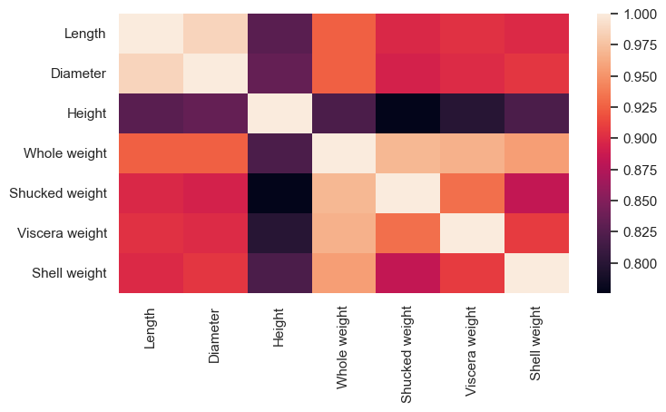

```python
sns.heatmap(df[num_vars].corr())
```

Several features are higly correlated, namely $\texttt{Length}$ and $\texttt{Diameter}$ (as expected).

#### Bivariate analysis

Let us also plot the pairwise relationships between the explanatory variables.

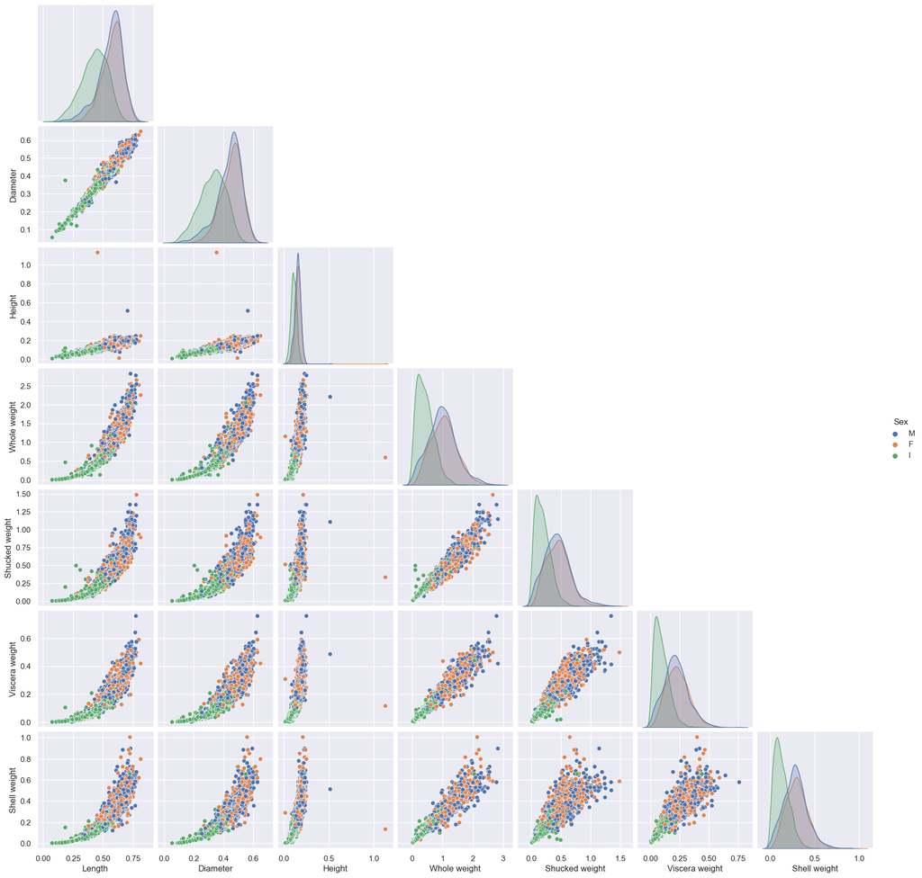

```python
sns.pairplot(data=df[num_vars + ['Sex']], hue='Sex', corner=True)
```

## Preprocessing

### Outliers

In the plots above, we can notice there are some outliers, especially for the $\texttt{Height}$ variable. There are several ways to approach the outliers. We will determine outliers by using Mahalanobis distance

##### Mahalanobis distance

```python
cov = np.cov(df[num_vars], rowvar=False)
cov_inv = np.linalg.inv(cov)
means = np.mean(df[num_vars], axis=0)

distances = []
for i, example in df[num_vars].iterrows():
    distances.append((example - means).T @ cov_inv @ (example - means))

df['M-Distance'] = distances
cutoff = chi2.ppf(0.95, len(num_vars))
sum((distances > cutoff)/df.shape[0])
```

```
0.08694610778443086
```

Based on Mahalanobis distance, we would label around 8.7% of datapoints as outliers. Let us see the feature distributions and bivariate plots again.

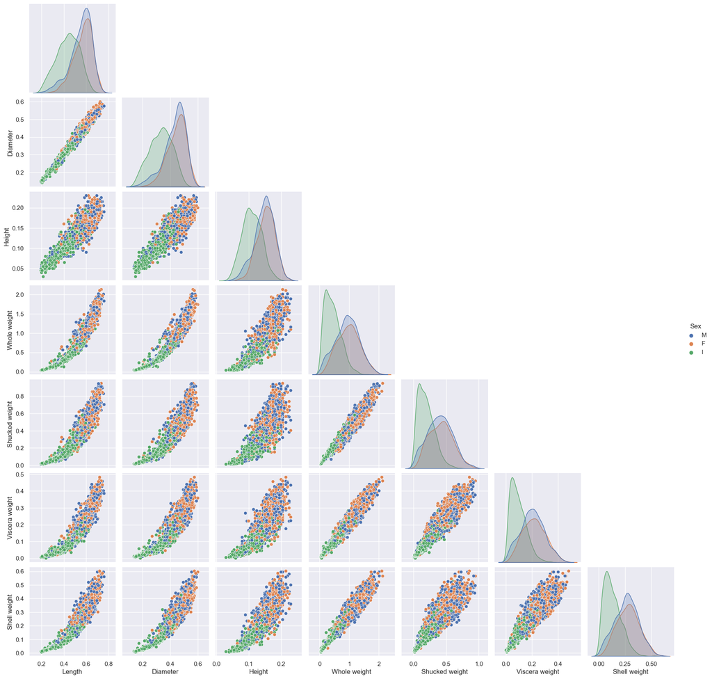

```python
df_in = df[distances <= cutoff]

sns.pairplot(data=df_in[num_vars+ ['Sex']], hue='Sex', corner=True)
```

### One hot fix

Considering we have three categories for attribute $\texttt{Sex}$, we will one-hot encode them.

```python
df_in = pd.get_dummies(df_in)
```

### Normalization

Since I have decided to use Linear Regression, we will apply the z-score normalization. Recall that the parameters mean and variance have to be fitted on the training data, not on the whole data. Otherwise, we will have a data leakage.

#### Splitting the data

```python
y = df_in['Rings']
X = df_in
X = X.drop(['Rings', 'M-Distance'], axis=1)
```

```python
X_train, X_test, y_train, y_test = train_test_split(X, y, random_state=33)
```

Now, we will fit the mean and variance estimations on the training set and transform both the training and test data

```python
mean = np.mean(X_train[num_vars], axis=0)
std = np.std(X_train[num_vars], axis=0)

X_train[num_vars] = (X_train[num_vars] - mean.T) / std.T
X_test[num_vars] = (X_test[num_vars] - mean.T) / std.T
X_train
```

|  | Length | Diameter | Height | Whole weight | Shucked weight | Viscera weight | Shell weight | Sex_F | Sex_I | Sex_M |
| --- | --- | --- | --- | --- | --- | --- | --- | --- | --- | --- |
| 3620 | 1.108662 | 1.069035 | 0.962771 | 1.148178 | 1.176251 | 1.720532 | 0.765672 | True | False | False |
| 2244 | -1.454991 | -1.323513 | -1.038572 | -1.268759 | -1.240889 | -1.264593 | -1.143890 | False | True | False |
| 139 | -1.275085 | -1.269136 | -1.181525 | -1.209326 | -1.228073 | -1.141917 | -1.081622 | False | False | True |
| 3214 | 0.478993 | 1.014659 | 0.676865 | 0.744966 | 0.596957 | 1.081592 | 0.765672 | True | False | False |
| 3757 | 0.029229 | 0.090265 | 0.105052 | -0.169833 | 0.020227 | -0.410970 | -0.234773 | False | True | False |
| ... | ... | ... | ... | ... | ... | ... | ... | ... | ... | ... |
| 2969 | 1.513449 | 1.123411 | 1.534583 | 1.773971 | 1.699152 | 2.415698 | 1.554403 | False | False | True |
| 639 | -0.060724 | -0.018487 | -0.180854 | -0.462336 | -0.597515 | -0.334297 | -0.230621 | True | False | False |
| 1922 | 0.838804 | 0.851530 | 0.105052 | 0.603959 | 0.522623 | 0.943581 | 0.392062 | False | False | True |
| 2682 | 0.928756 | 0.851530 | 0.390958 | 0.768273 | 0.825086 | 0.754455 | 0.682647 | False | False | True |
| 3405 | -1.589920 | -1.649769 | -1.753338 | -1.387624 | -1.317787 | -1.315708 | -1.434475 | False | True | False |

2859 rows × 10 columns

## Training

```python
model = LinearRegression()
model.fit(X_train, y_train)
model.coef_
```

```
array([-0.05974412,  0.91302825,  0.74466083,  7.13957947, -5.63901424,
       -2.0749007 ,  0.22610161,  0.24733179, -0.55284362,  0.30551183])
```

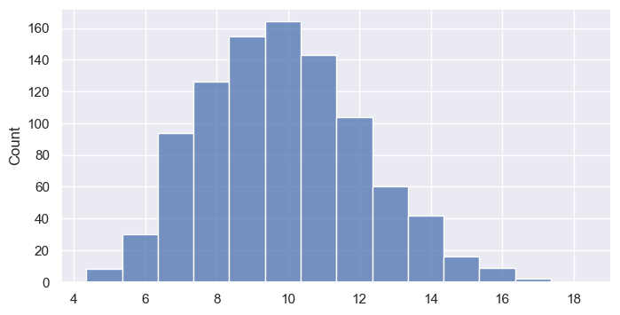

```python
y_pred = model.predict(X_test)
sns.histplot(y_pred, discrete=True)
```

## Evaluation

Let us check the regressions score:

### $R^2$

```python
print("R2 score: ", 1 - sum((y_test-y_pred) ** 2) / sum((y_test - np.mean(y_test)) ** 2))
```

```
R2 score:  0.5222381351571055
```

We see that prediction model has rather bad performance.

## Principle Component Analysis

Noticing that the "size" features and the "weight" features are correlated ammong themselves, let us see if we the data can "nicely" be captured by just two features. The data is already scaled and standardized. Let us start by computing the covarince matrix.

```python
m = X_train.shape[0]
Sigma = (1 / m) * np.dot( X_train[num_vars].T, X_train[num_vars])
U = np.linalg.eig(Sigma)[1]
Lambda = np.linalg.eig(Sigma)[0]
np.round(U, 4)
np.round(Lambda, 3)
```

```
array([6.549e+00, 1.810e-01, 1.230e-01, 1.100e-02, 3.000e-03, 5.600e-02,
       7.700e-02])
```

Notice that the first two eigenvalues are the biggest ones. Looking at the values, we can notice that even only one component explains a lot of variance in the data compared to others, but we will stick with two. Now that we got the eigenvectors, let's test if the first two will suffice for the decomposition.

```python
U_r = U[:, :2]
print(U_r)
```

```
[[-0.38042627 -0.17376591]
 [-0.3808758  -0.21901104]
 [-0.36482612 -0.69848051]
 [-0.38668157  0.28072917]
 [-0.3755808   0.49316573]
 [-0.37785864  0.33224088]
 [-0.37914464 -0.03948732]]
```

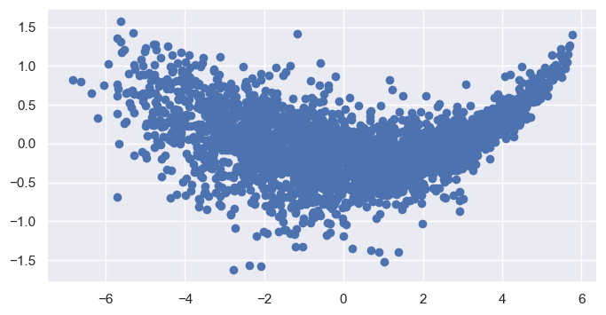

```python
Z_train = np.matmul(U_r.T,  X_train[num_vars].T.to_numpy())
plt.scatter(Z_train[0, :], Z_train[1, :])
```

Let us check if the reconstruction error in the data is small enough.

```python
X_train_approx = (U_r @ Z_train).T

numerator = (X_train_approx - X_train[num_vars]).to_numpy()
np.square(numerator)
numerator = np.sum(numerator)
numerator

denominator = X_train[num_vars].to_numpy()
denominator = np.square(denominator)
denominator = np.sum(denominator)
denominator
1-numerator/denominator
```

```
1.0
```

In the cell above, we have first calculated matrix $X_{trainapprox}$ which is the reconstruction of the $x^{(i)}$'s using $z^{(i)}$'s and the reduces eigenvector matrix $U_r$. Recall that $x^{(i)}$ is the $i$th training example and corresponds to the $i$th row in the $X_{train}$ matrix, while $z^{(i)}$ is the projection of the given example onto the subspace spanned by the columns of the matrix $U_r$.

To validate the calculations, we will check the results of the PCA done by the $\texttt{sklearn}$ library.

```python
from sklearn.decomposition import PCA

pca = PCA(n_components=2)
pca.fit(X_train[num_vars])
pca.components_.T
```

```
array([[ 0.38042627,  0.17376591],
       [ 0.3808758 ,  0.21901104],
       [ 0.36482612,  0.69848051],
       [ 0.38668157, -0.28072917],
       [ 0.3755808 , -0.49316573],
       [ 0.37785864, -0.33224088],
       [ 0.37914464,  0.03948732]])
```